# Lab 6

Anya Conti

March 29, 2017

```r
library(ggplot2)
library(dplyr)
```

**1.** The data is loaded into a data frame called debt. The dimensions of that are indeed 1171 rows and 4 columns.

```r
Debt <- read.csv("/Users/Anya/Documents/JuniorYear/Spring/Stat 597A/debt.csv")
dim(Debt)
```

```
## [1] 1171    4
```

**2.** The average GDP growth rate is calculated using tapply(), then this result is turned into a data fram and saved as AvgGrowth.country. The table is shown below.

```r
AvgGrowth.country <- data.frame("AvgGrowth" = tapply(Debt$growth, Debt$Country, mean))
AvgGrowth.country
```

```
##             AvgGrowth
## Australia    3.721597
## Austria      4.438030
## Belgium      3.176287
## Canada       3.652017
## Denmark      2.656741
## Finland      3.571897
## France       3.776350
## Germany      3.314818
## Greece       2.927692
## Ireland      3.933766
## Italy        3.252528
## Japan        4.447166
## Netherlands  3.031161
## New Zealand  3.069408
## Norway       3.826671
## Portugal     4.002797
## Spain        3.196547
## Sweden       3.065083
## UK           2.414808
## US           2.997120
```

**3.** Takes only the growth information of the data set, and splits it by country using split(). This is then saved as splitGrowth.country. Then sapply is used on this to find the mean within each split category (in this case by country).

```r
splitGrowth.country <- split(Debt$growth, Debt$Country)
sapply(splitGrowth.country, mean)
```

```
##   Australia     Austria     Belgium      Canada     Denmark     Finland
##    3.721597    4.438030    3.176287    3.652017    2.656741    3.571897
##      France     Germany      Greece     Ireland       Italy       Japan
##    3.776350    3.314818    2.927692    3.933766    3.252528    4.447166
## Netherlands New Zealand      Norway    Portugal       Spain      Sweden
##    3.031161    3.069408    3.826671    4.002797    3.196547    3.065083
##          UK          US
##    2.414808    2.997120
```

**4.** Creates a data frame called AvgGrowth.year. Uses tapply to find the mean growth by year, and saves this as an “AvgGrowth” column of the data frame. Creates a “year” column using seq(). Uses qplot to plot the AverageGrowth as a function of year.

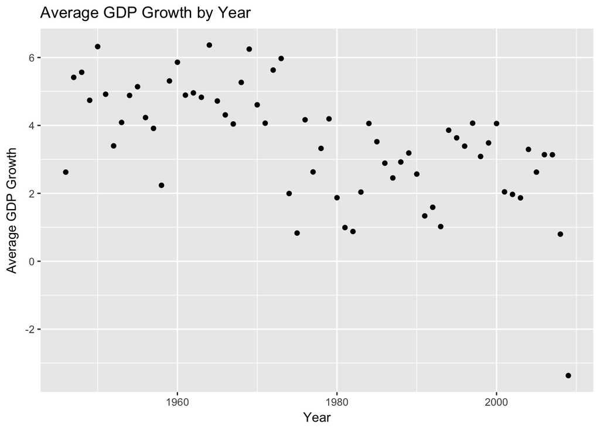

```r
AvgGrowth.year <- data.frame("AvgGrowth" = tapply(Debt$growth, Debt$Year, mean),"year" = seq(from = 1946, to = 2009, by =1))
qplot(x = AvgGrowth.year$year, y = AvgGrowth.year$AvgGrowth, xlab = "Year", ylab = "Average GDP Growth", main="Average GDP Growth by Year")
```

**5.a.** Uses cor() to calculate the correlation coefficient between GDP growth and debt ratio over the whole data set.

```r
cor(Debt$growth,Debt$ratio)
```

```
## [1] -0.199468
```

**5.b.** Creates a function called CorByCat (correlation by category) that takes in a data frame and finds the correlation between the growth and debt ratio of it, and then returns that correlation. Then uses split() to split the data set by country, and saves this to splitByCountry. Then uses sapply() to use CorByCat on each country category of that data set, and saves these correlations to corsByCountry. Then uses ggplot() to make a histogram.

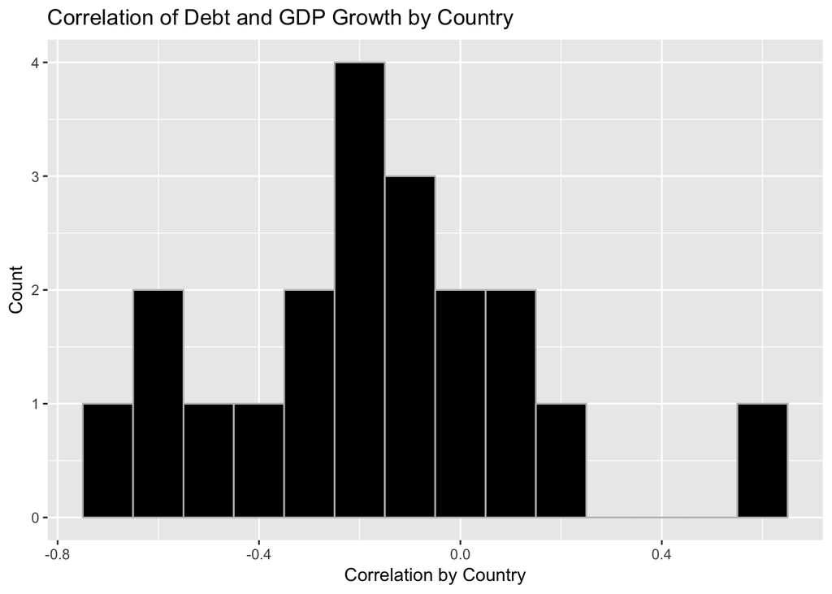

```r
CorByCat <- function(df){
  correlation <- cor(df$growth,df$ratio)
  return(correlation)
}

splitByCountry <- split(Debt, Debt$Country)
corsByCountry <- sapply(splitByCountry, CorByCat)
ggplot() + geom_histogram(binwidth = 0.1, aes(corsByCountry), fill = "black", color = "grey") + xlab("Correlation by Country") + ylab("Count") + ggtitle("Correlation of Debt and GDP Growth by Country")
```

**5.c.** Uses split() to split the data set by year, and saves this to splitByYear. Then uses sapply() to use CorByCat on each year category of that data set, and saves these correlations to corsByYear. Then uses ggplot() to make a histogram.

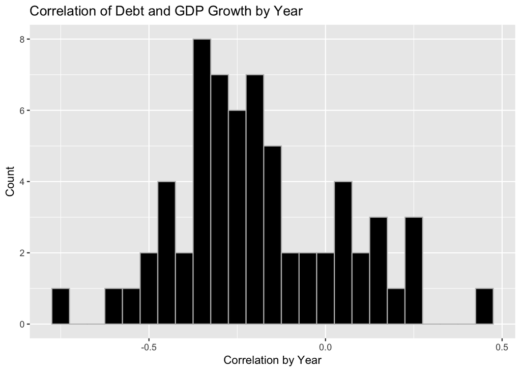

```r
splitByYear <- split(Debt, Debt$Year)
corsByYear <- sapply(splitByYear, CorByCat)
ggplot() + geom_histogram(binwidth = 0.05, aes(corsByYear), fill = "black", color = "grey") + xlab("Correlation by Year") + ylab("Count") + ggtitle("Correlation of Debt and GDP Growth by Year")
```

**5.d.** The only country that appears to be an outlier is the highest one, which is Norway with a correlation of 0.5629. The only years that appear to be outliers are the lowest and highest ones: 1978 with a correlation of 0.4307 and 1957 with a correlation of -0.7550. These were found by sorting in the particular order needed, and taking the first row.

```r
sort(corsByCountry, decreasing = TRUE)[1]
```

```
##    Norway
## 0.5629129
```

```r
sort(corsByYear, decreasing = TRUE)[1]
```

```
##      1978
## 0.4306586
```

```r
sort(corsByYear)[1]
```

```
##       1957
## -0.7549859
```

**6.** The cloud seems weakly correlated with a negative linear relationship. The points are mostly clustered near low GDP growth and low Debt ratio, though more variance in Debt Ratio it appears. This makes sense with a correlation coefficient of -0.1995: a downward slope, and not strongly linearly correlated, but not a correlation of 0 either.

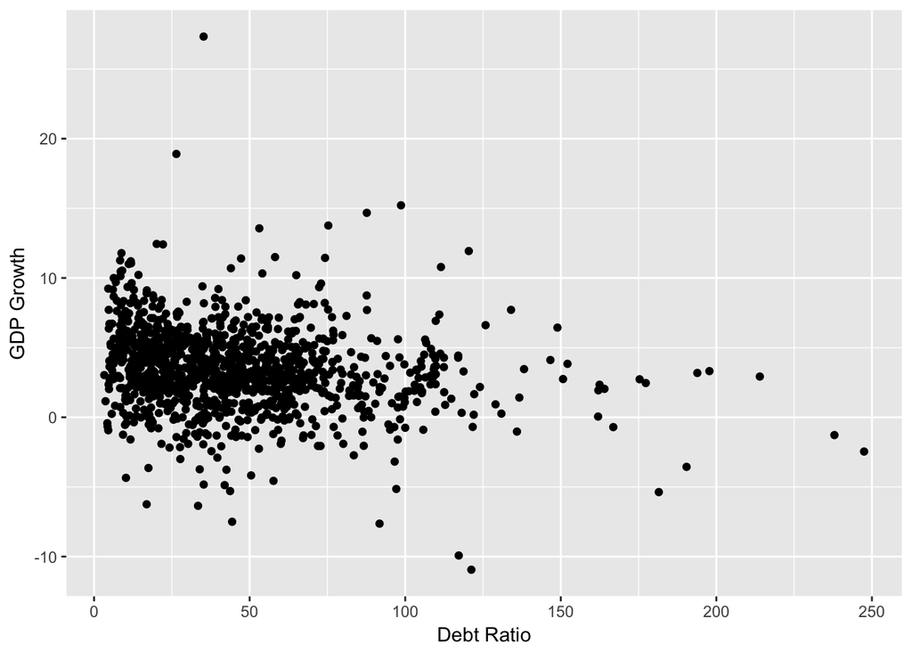

```r
qplot(y= Debt$growth, x = Debt$ratio, xlab = "Debt Ratio", ylab = "GDP Growth")
```